# PRÁCTICA 2: Limpieza y validación de datos

Irene Martínez de Soto

# Descripción del dataset.

El dataset seleccionado contiene los datos reporte mundial de felicidad mundial generado el año 2019. Con este conjunto de datos se pretende analizar qué características son más determinantes a la hora de tener un mayor nivel de felicidad en su población.

Los datos están disponibles públicamente en https://www.kaggle.com/unsdsn/world-happiness y se puede obtener más información respecto al análisis oficial realizado en https://worldhappiness.report/ed/2019/.

Las reflexiones obtenidas a partir del análisis pueden ser empleadas por otros países para intentar mejorar el suyo entendiendo qué factores afectarán más al resultado final.

El dataset contiene un único archivo en formato csv, por lo que no es necesario realizar ninguna integración adicional de los datos.

El conjunto de datos tiene un registro por país. Los datos principales que se recogen en cada uno de ellos son:

- **Overall rank** Clasificación global
- **Country or region** Nombre del país o región
- **Score** Puntuación de felicidad

Los demás atributos incluidos en el conjunto de datos están formados por valoraciones de distintos dominios relativos a la vida en un determinado país. Las valoraciones representan el porcentaje en el que cada uno de ellos influyó positivamente en el cálculo de la calificación final de la región. Los dominios son:

- **GDP per capita** Influencia del PIB per cápita en la clasificación.
- **Social support** Influencia del apoyo social en la clasificación.
- **Healthy life expectancy** Influencia de la esperanza de vida en la clasificación.
- **Freedom** Influencia de la libertad en la clasificación.
- **Generosity** Influencia de la generosidad en la clasificación.
- **Corruption** Influencia de la percepción de corrupción en la clasificación.

El código de esta práctica así como todos los datos utilizados durante la misma están disponibles en: https://github.com/irenemds/Practica2_M2.851_20191

# Importancia y objetivo de los análisis

Con el conjunto de datos a analizar, se pretende determinar cual de los dominios incluidos en el reporte influye más sobre la clasificación y las calificaciones dadas por la población. Esto permitirá además predecir como las mejoras en cada uno de los dominios puede influis de manera positiva a la calificación obtenida por el país, permitiendo a los gobiernos priorizar aquellas que puedan producir un mayor impacto.

Además se pueden crear agrupaciones de los países para revisar las relaciones y similitudes entre ellos y se podría intentar aplicar un modeo de regresión para estimar la calificación obtenida en función de la valoración de los distintos dominios.

Como se mencionó anteriormente, estos análisis pueden ser empleados desde el punto de vista político para comprender mejor las carencias presentes en la sociedad de un país y poder poner medidas para mejorar la situación y así la felicidad de la población.

# Limpieza de datos

Para comenzar el proyecto, se realiza la carga inicial de los datos seguida de una representación inicial para verificar que los datos mostrados son correctos.

```r
happiness_report <- read.csv("../data/2019.csv")
colnames(happiness_report)[2] <- "Country"
head(happiness_report)
```

```
##   Overall.rank     Country Score GDP.per.capita Social.support
## 1            1     Finland 7.769          1.340          1.587
## 2            2     Denmark 7.600          1.383          1.573
## 3            3      Norway 7.554          1.488          1.582
## 4            4     Iceland 7.494          1.380          1.624
## 5            5 Netherlands 7.488          1.396          1.522
## 6            6 Switzerland 7.480          1.452          1.526
##   Healthy.life.expectancy Freedom.to.make.life.choices Generosity
## 1                   0.986                        0.596      0.153
## 2                   0.996                        0.592      0.252
## 3                   1.028                        0.603      0.271
## 4                   1.026                        0.591      0.354
## 5                   0.999                        0.557      0.322
## 6                   1.052                        0.572      0.263
##   Perceptions.of.corruption
## 1                     0.393
## 2                     0.410
## 3                     0.341
## 4                     0.118
## 5                     0.298
## 6                     0.343
```

A continuación se comprueba que el tipo de variable asignada a cada uno de los atributos es correcto.

```r
# Tipo de dato asignado a cada campo
sapply(happiness_report, function(x) class(x))
```

```
##                 Overall.rank                      Country
##                    "integer"                     "factor"
##                        Score               GDP.per.capita
##                    "numeric"                    "numeric"
##               Social.support      Healthy.life.expectancy
##                    "numeric"                    "numeric"
## Freedom.to.make.life.choices                   Generosity
##                    "numeric"                    "numeric"
##    Perceptions.of.corruption
##                    "numeric"
```

Se observa que los tipos de variables asignados automáticamente son los correctos.

## Selección de los datos de interés

En este caso todos los datos son relevantes para el análisis, solo se eliminará el campo del ranking global ya que no aporta información adicional.

```r
# Eliminar las primera columna
happiness_report <- happiness_report[, -1]
```

## Elementos vacíos

En los campos de la influencia de cada uno de los dominios en la calificación del país, es posible que se encuentre algún 0 si el mismo no ha influido nada en la decisión, por lo que no se tomará 0 como un valor vacío en este caso.

Se consideran únicamente los valores vacíos.

```r
# Números de valores desconocidos por campo
sapply(happiness_report, function(x) sum(is.na(x)))
```

```
##                      Country                        Score
##                            0                            0
##               GDP.per.capita               Social.support
##                            0                            0
##      Healthy.life.expectancy Freedom.to.make.life.choices
##                            0                            0
##                   Generosity    Perceptions.of.corruption
##                            0                            0
```

No se ha encontrado ningún valor vacío.

Si se hubiera encontrado algún registro con el campo “Country” vacío, ese habría sido eliminado.

Para los demás atributos, se habría utilizado algún algoritmo para predecir un valor apropiado que no distorsione los datos y los resultados del análisis.

## Valores extremos

Los valores extremos o outliers son aquellos que parecen no ser congruentes sin los comparamos con el resto de los datos.

Para identificar visualmente estos valores, se utilizan las gráficas de tipo *boxplot*, como se representa a continuación:

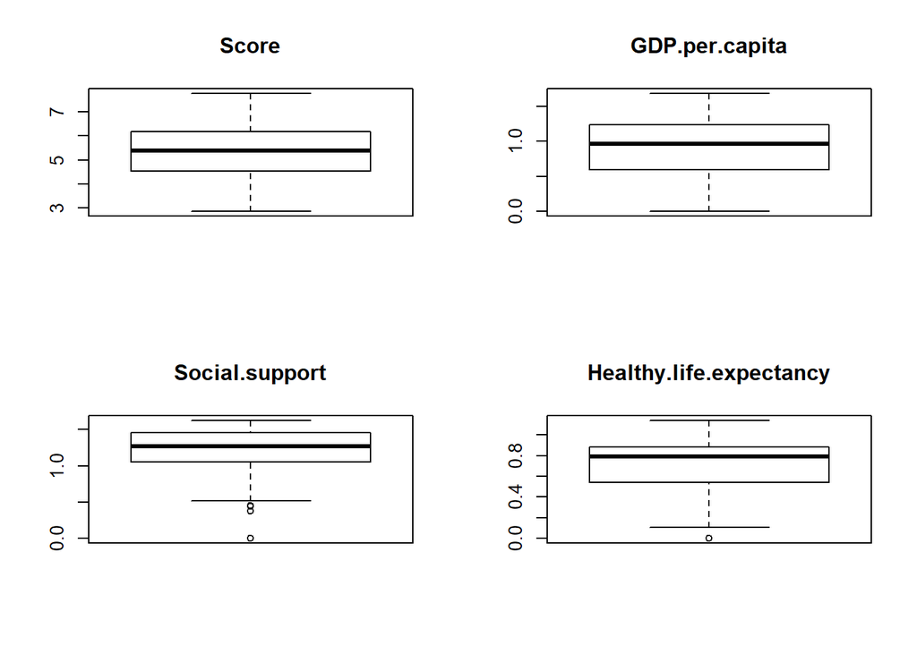

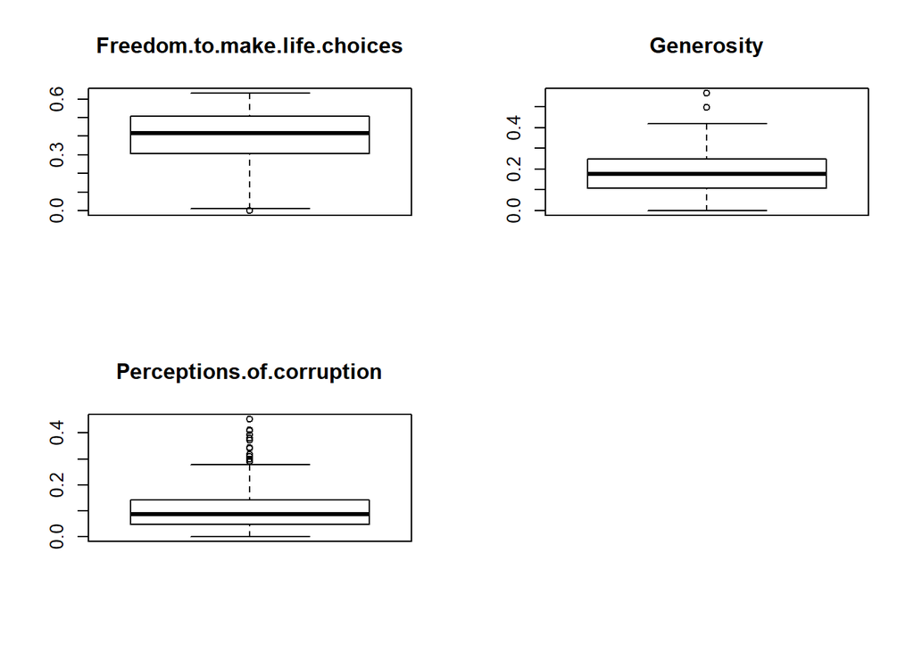

```r
par(mfrow=c(2,2))
for(i in 1:ncol(happiness_report)) {
  if (is.numeric(happiness_report[,i])){
    boxplot(happiness_report[,i], main = colnames(happiness_report)[i], width = 100)
  }
}
```

Modificar o eliminar estos registros causaría una pérdida de información, por lo que en este caso los valores se mantendrán.

# Análisis de los datos

En los siguientes apartados se incluyen los pasos para realizar el proyecto de análisis descrito anteriormente, determinar los dominios que influyen en mayor manera sobre la calificación de felicidad obtenida.

## Selección de los grupos de datos a analizar

Se realizan agrupaciones en función del valor de los atributos de la percepción de los distintos dominios incluidos en el dataset:

“GDP.per.capita”, “Social.support”, “Freedom.to.make.life.choices”, “Generosity”, “Healthy.life.expectancy” y “Perceptions.of.corruption”

En función de sus valores máximo y mínimo, se crean 4 grupos equidistantes sobre los que se realizarán las comparaciones.

Comenzando por el atributo **GDP.per.capita**:

```r
max_value <- max(happiness_report$GDP.per.capita, na.rm = TRUE)
min_value <- min(happiness_report$GDP.per.capita, na.rm = TRUE)

range_step <- (max_value - min_value) / 4

happiness_report.GDP.verylow <- happiness_report[happiness_report$GDP.per.capita <= min_value+range_step,]
happiness_report.GDP.low <- happiness_report[(happiness_report$GDP.per.capita <= min_value+range_step*2) & (happiness_report$GDP.per.capita > min_value+range_step),]
happiness_report.GDP.high <- happiness_report[(happiness_report$GDP.per.capita <= min_value+range_step*3) & (happiness_report$GDP.per.capita > min_value+range_step*2),]
happiness_report.GDP.veryhigh <- happiness_report[(happiness_report$GDP.per.capita <= min_value+range_step*4) & (happiness_report$GDP.per.capita > min_value+range_step*3),]
```

**Social.support**:

```r
max_value <- max(happiness_report$Social.support, na.rm = TRUE)
min_value <- min(happiness_report$Social.support, na.rm = TRUE)

range_step <- (max_value - min_value) / 4

happiness_report.social.verylow <- happiness_report[happiness_report$Social.support <= min_value+range_step,]
happiness_report.social.low <- happiness_report[(happiness_report$Social.support <= min_value+range_step*2) & (happiness_report$Social.support > min_value+range_step),]
happiness_report.social.high <- happiness_report[(happiness_report$Social.support <= min_value+range_step*3) & (happiness_report$Social.support > min_value+range_step*2),]
happiness_report.social.veryhigh <- happiness_report[(happiness_report$Social.support <= min_value+range_step*4) & (happiness_report$Social.support > min_value+range_step*3),]
```

**Freedom.to.make.life.choices**:

```r
max_value <- max(happiness_report$Freedom.to.make.life.choices, na.rm = TRUE)
min_value <- min(happiness_report$Freedom.to.make.life.choices, na.rm = TRUE)

range_step <- (max_value - min_value) / 4

happiness_report.freedom.verylow <- happiness_report[happiness_report$Freedom.to.make.life.choices <= min_value+range_step,]
happiness_report.freedom.low <- happiness_report[(happiness_report$Freedom.to.make.life.choices <= min_value+range_step*2) & (happiness_report$Freedom.to.make.life.choices > min_value+range_step),]
happiness_report.freedom.high <- happiness_report[(happiness_report$Freedom.to.make.life.choices <= min_value+range_step*3) & (happiness_report$Freedom.to.make.life.choices > min_value+range_step*2),]
happiness_report.freedom.veryhigh <- happiness_report[(happiness_report$Freedom.to.make.life.choices <= min_value+range_step*4) & (happiness_report$Freedom.to.make.life.choices > min_value+range_step*3),]
```

**Generosity**:

```r
max_value <- max(happiness_report$Generosity, na.rm = TRUE)
min_value <- min(happiness_report$Generosity, na.rm = TRUE)

range_step <- (max_value - min_value) / 4

happiness_report.Generosity.verylow <- happiness_report[happiness_report$Generosity <= min_value+range_step,]
happiness_report.Generosity.low <- happiness_report[(happiness_report$Generosity <= min_value+range_step*2) & (happiness_report$Generosity > min_value+range_step),]
happiness_report.Generosity.high <- happiness_report[(happiness_report$Generosity <= min_value+range_step*3) & (happiness_report$Generosity > min_value+range_step*2),]
happiness_report.Generosity.veryhigh <- happiness_report[(happiness_report$Generosity <= min_value+range_step*4) & (happiness_report$Generosity > min_value+range_step*3),]
```

**Healthy.life.expectancy**:

```r
max_value <- max(happiness_report$Healthy.life.expectancy, na.rm = TRUE)
min_value <- min(happiness_report$Healthy.life.expectancy, na.rm = TRUE)

range_step <- (max_value - min_value) / 4

happiness_report.LifeExpectancy.verylow <- happiness_report[happiness_report$Healthy.life.expectancy <= min_value+range_step,]
happiness_report.LifeExpectancy.low <- happiness_report[(happiness_report$Healthy.life.expectancy <= min_value+range_step*2) & (happiness_report$Healthy.life.expectancy > min_value+range_step),]
happiness_report.LifeExpectancy.high <- happiness_report[(happiness_report$Healthy.life.expectancy <= min_value+range_step*3) & (happiness_report$Healthy.life.expectancy > min_value+range_step*2),]
happiness_report.LifeExpectancy.veryhigh <- happiness_report[(happiness_report$Healthy.life.expectancy <= min_value+range_step*4) & (happiness_report$Healthy.life.expectancy > min_value+range_step*3),]
```

**Perceptions.of.corruption**:

```r
max_value <- max(happiness_report$Perceptions.of.corruption, na.rm = TRUE)
min_value <- min(happiness_report$Perceptions.of.corruption, na.rm = TRUE)

range_step <- (max_value - min_value) / 4

happiness_report.Corruption.verylow <- happiness_report[happiness_report$Perceptions.of.corruption <= min_value+range_step,]
happiness_report.Corruption.low <- happiness_report[(happiness_report$Perceptions.of.corruption <= min_value+range_step*2) & (happiness_report$Perceptions.of.corruption > min_value+range_step),]
happiness_report.Corruption.high <- happiness_report[(happiness_report$Perceptions.of.corruption <= min_value+range_step*3) & (happiness_report$Perceptions.of.corruption > min_value+range_step*2),]
happiness_report.Corruption.veryhigh <- happiness_report[(happiness_report$Perceptions.of.corruption <= min_value+range_step*4) & (happiness_report$Perceptions.of.corruption > min_value+range_step*3),]
```

Una vez creados los grupos por cada uno de los dominios disponibles en el dataset, se procederá a realizar las comparaciones para comprobar cual de ellos influyó en mayor medida en los resultados obtenidos.

## Comprobación de la normalidad y homogeneidad en la varianza

### Comprobación normalidad

Se utilizará el test de normalidad de Anderson Darling. Se considerará como hipotesis nula que la variable sigue una distribución normal.

Se aplicará el valor de significación 0.05, utilizado de manera standard.

```r
col.names = colnames(happiness_report)
#Se aplica el test sobre cada una de las variables numéricas
for (i in 1:ncol(happiness_report)) {
  if (is.integer(happiness_report[,i]) | is.numeric(happiness_report[,i])) {
    p_val = ad.test(happiness_report[,i])$p.value
    if (p_val < 0.05) {
      cat(col.names[i])
      if (i < ncol(happiness_report) - 1) cat(", ")
      if (i %% 3 == 0) cat("\n")
    }
  }
}
```

```
## GDP.per.capita,
## Social.support, Healthy.life.expectancy, Freedom.to.make.life.choices,
## GenerosityPerceptions.of.corruption
```

### Comprobación homogeneidad varianzas

```r
fligner.test(Score ~ GDP.per.capita, data = happiness_report)
```

```
##
##  Fligner-Killeen test of homogeneity of variances
##
## data:  Score by GDP.per.capita
## Fligner-Killeen:med chi-squared = 143.68, df = 145, p-value = 0.5154
```

```r
fligner.test(Score ~ Social.support, data = happiness_report)
```

```
##
##  Fligner-Killeen test of homogeneity of variances
##
## data:  Score by Social.support
## Fligner-Killeen:med chi-squared = 149.68, df = 144, p-value = 0.3558
```

```r
fligner.test(Score ~  Healthy.life.expectancy, data = happiness_report)
```

```
##
##  Fligner-Killeen test of homogeneity of variances
##
## data:  Score by Healthy.life.expectancy
## Fligner-Killeen:med chi-squared = 128.15, df = 118, p-value = 0.2464
```

```r
fligner.test(Score ~ Generosity, data = happiness_report)
```

```
##
##  Fligner-Killeen test of homogeneity of variances
##
## data:  Score by Generosity
## Fligner-Killeen:med chi-squared = 125.08, df = 117, p-value = 0.2878
```

```r
fligner.test(Score ~ Perceptions.of.corruption, data = happiness_report)
```

```
##
##  Fligner-Killeen test of homogeneity of variances
##
## data:  Score by Perceptions.of.corruption
## Fligner-Killeen:med chi-squared = 118.09, df = 112, p-value = 0.3284
```

## Aplicación de pruebas estadísticas

En este apartado se utilizarán 3 métodos de contraste para comprobar cuales son los dominios incluidos en el estudio que más afectan el resultado del nivel de felicidad.

### Identificación de los dominios más relevantes

#### Correlación entre variables

En este caso se realizará una prueba de correlación de las veriables. Se comprbará cuál de los dominios tiene una mayor de correlación con la variable “Score” para obtener una idea inicial de cuál es el más influyente.

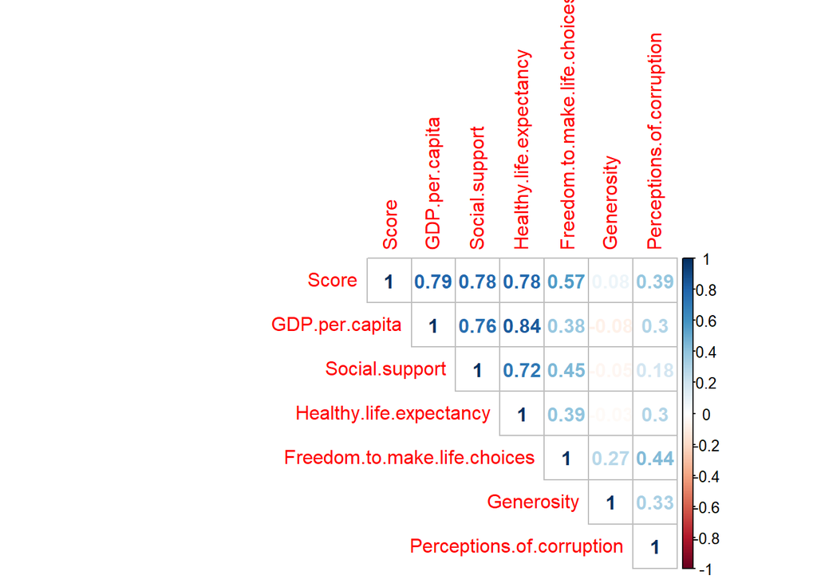

```r
correlacion<-round(cor(happiness_report[, -1]), 3)

corrplot(correlacion, method="number", type="upper")
```

Se comprueba que la variable con mayor coeficiente de correlación con la puntuación, “Score” es GDP.per.capita, ligeramente por encima de Social.support y Healthy-life.expectancy.

Tras este primer análisis se comprueba que estas 3 son las más influyentes en la puntuación.

#### Contraste entre puntuaciones con alto nivel de Generosidad y bajo

```r
happiness_report.Generosity.low.score <- happiness_report[(happiness_report$Generosity <= min_value+range_step*2) & (happiness_report$Generosity > min_value+range_step),]$Score
happiness_report.Generosity.high.score <- happiness_report[(happiness_report$Generosity <= min_value+range_step*3) & (happiness_report$Generosity > min_value+range_step*2),]$Score
```

Tras haber extraido los valores de la puntuación a comparar, se utiliza el método contraste de hipótesis de las dos muestras sobre la diferencia de medias. La hipótesis nula será que ambas medias sean iguales y la alternativa que la diferencia sea menor de 0.

Se toma como valor de significación 0.05.

```r
t.test(happiness_report.Generosity.low.score, happiness_report.Generosity.high.score,
alternative = "less")
```

```
##
##  Welch Two Sample t-test
##
## data:  happiness_report.Generosity.low.score and happiness_report.Generosity.high.score
## t = -1.6738, df = 76.493, p-value = 0.04913
## alternative hypothesis: true difference in means is less than 0
## 95 percent confidence interval:
##          -Inf -0.002145758
## sample estimates:
## mean of x mean of y
##  5.258197  5.668349
```

Se observa que el valor de p es ligeramente inferior a 0.05, por lo que se descarta la hipótesis nula, aunque por muy poco. De esta manera se obtiene que la media de felicidad para países con la generosidad más baja el nivel de felicidad también es menor, a pesar de que como se observo en el apartado anterior y en este se pudo entrever, la diferencia producida por este dominio no es muy significativa.

### Agrupación de países

#### Algoritmo K-means

Para realizar la agrupación de los países en función de la información conocida, se utilizará el algoritmo de k-means.

```r
#Se crea el modelo eliminando la columna con el nombre del país, ya que no aporta información.
clusters <- kmeans(happiness_report[,-1], 4)

# Se almacena el grupo como una columna más.
happiness_report$Grupo <- as.factor(clusters$cluster)
```

Una vez creado el modelo y las agrupaciones, se verifican los datos obtenidos, en este caso los países incluidos en cada grupo y la media del valor puntuación en cada grupo.

```r
print (happiness_report[happiness_report$Grupo == "1",]$Country)
```

```
##  [1] Nigeria                 Morocco                 Bhutan
##  [4] Cameroon                Ghana                   Ivory Coast
##  [7] Nepal                   Jordan                  Benin
## [10] Congo (Brazzaville)     Gabon                   Laos
## [13] South Africa            Albania                 Venezuela
## [16] Cambodia                Palestinian Territories Senegal
## [19] Somalia                 Namibia                 Niger
## [22] Burkina Faso            Armenia                 Iran
## [25] Guinea                  Georgia                 Gambia
## [28] Kenya                   Mauritania              Mozambique
## [31] Tunisia                 Bangladesh              Iraq
## [34] Congo (Kinshasa)        Mali                    Sierra Leone
## [37] Sri Lanka               Myanmar                 Chad
## [40] Ukraine                 Ethiopia                Swaziland
## [43] Uganda                  Egypt                   Zambia
## [46] India
## 156 Levels: Afghanistan Albania Algeria Argentina Armenia Australia ... Zimbabwe
```

```r
mean(happiness_report[happiness_report$Grupo == "1",]$Score)
```

```
## [1] 4.596848
```

```r
print (happiness_report[happiness_report$Grupo == "2",]$Country)
```

```
##  [1] Guatemala              Panama                 Brazil
##  [4] Uruguay                El Salvador            Italy
##  [7] Bahrain                Slovakia               Trinidad & Tobago
## [10] Poland                 Uzbekistan             Lithuania
## [13] Colombia               Slovenia               Nicaragua
## [16] Kosovo                 Argentina              Romania
## [19] Cyprus                 Ecuador                Kuwait
## [22] Thailand               Latvia                 South Korea
## [25] Estonia                Jamaica                Mauritius
## [28] Japan                  Honduras               Kazakhstan
## [31] Bolivia                Hungary                Paraguay
## [34] Northern Cyprus        Peru                   Portugal
## [37] Pakistan               Russia                 Philippines
## [40] Serbia                 Moldova                Libya
## [43] Montenegro             Tajikistan             Croatia
## [46] Hong Kong              Dominican Republic     Bosnia and Herzegovina
## [49] Turkey                 Malaysia               Belarus
## [52] Greece                 Mongolia               North Macedonia
## [55] Kyrgyzstan             Turkmenistan           Algeria
## [58] Azerbaijan             Lebanon                Indonesia
## [61] China                  Vietnam                Bulgaria
## 156 Levels: Afghanistan Albania Algeria Argentina Armenia Australia ... Zimbabwe
```

```r
mean(happiness_report[happiness_report$Grupo == "2",]$Score)
```

```
## [1] 5.744476
```

```r
print (happiness_report[happiness_report$Grupo == "3",]$Country)
```

```
##  [1] Togo                     Liberia                  Comoros
##  [4] Madagascar               Lesotho                  Burundi
##  [7] Zimbabwe                 Haiti                    Botswana
## [10] Syria                    Malawi                   Yemen
## [13] Rwanda                   Tanzania                 Afghanistan
## [16] Central African Republic South Sudan
## 156 Levels: Afghanistan Albania Algeria Argentina Armenia Australia ... Zimbabwe
```

```r
mean(happiness_report[happiness_report$Grupo == "3",]$Score)
```

```
## [1] 3.543941
```

```r
print (happiness_report[happiness_report$Grupo == "4",]$Country)
```

```
##  [1] Finland              Denmark              Norway
##  [4] Iceland              Netherlands          Switzerland
##  [7] Sweden               New Zealand          Canada
## [10] Austria              Australia            Costa Rica
## [13] Israel               Luxembourg           United Kingdom
## [16] Ireland              Germany              Belgium
## [19] United States        Czech Republic       United Arab Emirates
## [22] Malta                Mexico               France
## [25] Taiwan               Chile                Saudi Arabia
## [28] Qatar                Spain                Singapore
## 156 Levels: Afghanistan Albania Algeria Argentina Armenia Australia ... Zimbabwe
```

```r
mean(happiness_report[happiness_report$Grupo == "4",]$Score)
```

```
## [1] 6.996767
```

Tras revisar los datos se puede predecir que los grupos creados sí contendrán países en los que se observe una puntuación de felicidad similar. A confinuación se representará un histograma con los valores de felicidad distinguiendo por grupos para comprobar de manera visual su distribución.

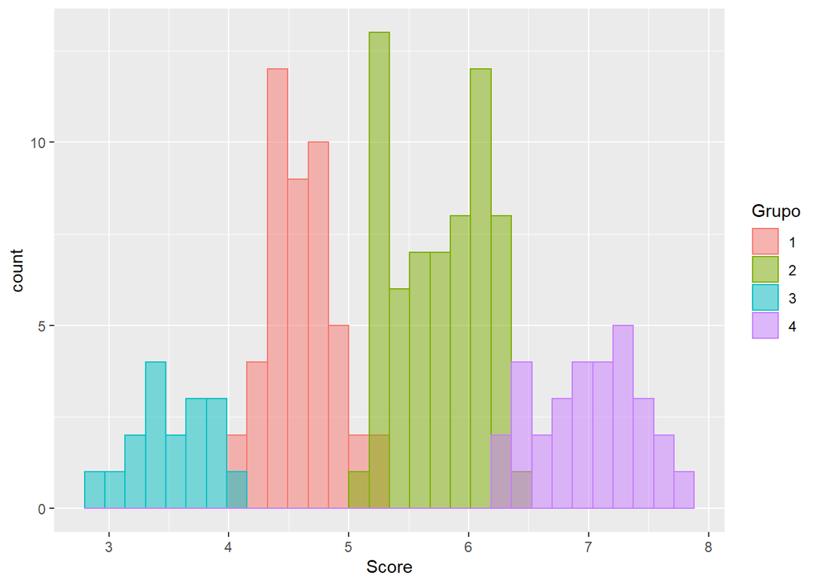

```r
ggplot(happiness_report, aes(x=Score, color=Grupo, fill=Grupo)) +
  geom_histogram(alpha=0.5, position="identity")
```

### Predicción de nuevas calificaciones

#### Regresión lineal

Por último, como se comentó en el comienzo del proyecto, se considera que un posible punto de interés de este proyecto sería predecir como los cambios en la percepción de los dominios por la población podrían afectar al nivel general de felicidad en un país.

Puesto que se dispone de variables numéricas para medir estos datos, se puede definir una función que modele la distribución de los datos y que se pueda usar para predecir como afectarían dichos cambios en la puntuación final.

```r
#Se almacenan los datos en nuevas variables para escribir la fórmula de regresión lineal de manera más sencilla.
generosidad = happiness_report$Generosity
esperanzavida = happiness_report$Healthy.life.expectancy
corrupcion = happiness_report$Perceptions.of.corruption
GDPpercapita = happiness_report$GDP.per.capita
libertad = happiness_report$Freedom.to.make.life.choices
apoyosociedad = happiness_report$Social.support
puntuacion = happiness_report$Score


# Generación de varios modelos
#El primer modelo contiene todos los dominios
modelo1 <- lm(puntuacion ~ generosidad + esperanzavida + corrupcion + GDPpercapita +
libertad + apoyosociedad, data = happiness_report)
#El segundo contiene todos menos generosidad ya que es el que menos afecta a la puntuación final
modelo2 <- lm(puntuacion ~ esperanzavida + corrupcion + GDPpercapita +
libertad + apoyosociedad, data = happiness_report)
#Por último, el tercero solo contiene los dominios que más influyen a la felicidad
modelo3 <- lm(puntuacion ~ esperanzavida + GDPpercapita + apoyosociedad, data = happiness_report)

tabla.coeficientes <- matrix(c(1, summary(modelo1)$r.squared,
2, summary(modelo2)$r.squared,
3, summary(modelo3)$r.squared),
ncol = 2, byrow = TRUE)
colnames(tabla.coeficientes) <- c("Modelo", "R^2")

tabla.coeficientes
```

```
##      Modelo       R^2
## [1,]      1 0.7791638
## [2,]      2 0.7777287
## [3,]      3 0.7263250
```

Se obtiene que el primer modelo, que incluye todos los dominios del reporte, es el que ofrece un mejor resultado.

Una vez creado y seleccionado el modelo, se utilizará para preveer la calificación de un nuevo país que se incorporará al raking, con valores aleatorios.

```r
newdata <- data.frame(
    generosidad = 0.87354,
    esperanzavida = 0.65749,
    corrupcion = 0.2321421,
    GDPpercapita = 0.78273812,
    libertad = 0.9865,
    apoyosociedad = 0.2312320
)
#Utilizar el modelo para calcular el nivel de felicidad.
predict(modelo1, newdata)
```

```
##        1
## 5.459695
```

Se puede representar el nuevo país en el histograma anterior para comprobar como se posiciona este valor en el resto de las calificaciones.

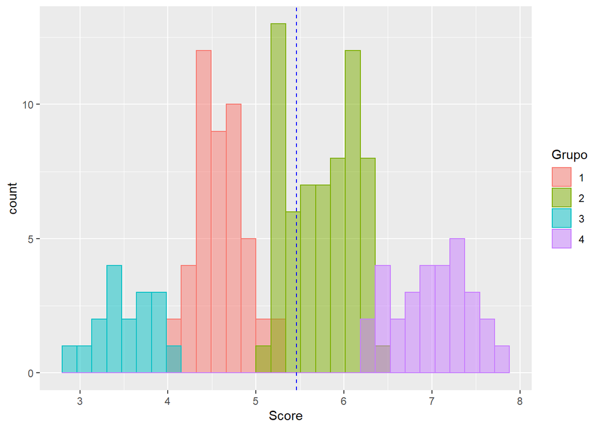

```r
ggplot(happiness_report, aes(x=Score, color=Grupo, fill=Grupo)) +
  geom_histogram(alpha=0.5, position="identity")+
  geom_vline(aes(xintercept=5.459695), color="blue",
             linetype="dashed")
```

## Exportación de datos

```r
# Exportación de los datos limpios en .csv
write.csv(happiness_report, "happiness_report_clean.csv")
```

# Conclusiones

Con las pruebas realizadas se han podido resolver las preguntas marcadas al inicio del proyecto. Mediante el análisis de la correlación de las variables con la puntuación de cada país se ha comprobado qué variables son las que más relación tienen con la puntuación obtenida, lo que puede permitir centrar el análisis en las mismas. En este caso, dado el tamaño de los datos, no ha sido necesario. Con esta información se podrían priorizar distintas medidas políticas que puedan afectar más a estos campos para obtener un mayor nivel de felicidad en la población con menos esfuerzo.

A continuación se utilizó un algoritmo de agrupación para crear grupos en la población de los datos que permitan establecer relaciones entre los distintos países y comprobar qué tienen en común aquellos que tienen un mayor nivel de felicidad en comparación con los que lo tienen menor.

Por último, utilizando un regresión lineal, se creó el modelo que permitió predecir el nivel de felicidad de un nuevo país, pero también podría ser utilizado para valorar la influencia de un nuevo valor en alguno de los dominios.

Para realizar los análisis se realizó un proceso de limpieza de datos sobre el conjunto bajo análisis. El conjunto de datos no disponía de valores nulos, por lo que simplemente fue necesario eliminar los atributos que no aportaban valor al análisis.